# Lecture #10: Partial Derivatives

MATH 145 – Calculus I

Torin Quinlivan

tquinlivan@knox.edu

Knox College

October 7, 2025

## Derivatives of Single Variable Functions

So far, everything we have discussed applies to functions of a single variable, of the form $f(x)$. What if we want to expand this to multivariable functions?

Derivatives are “rates of change”, how would you define rates of change for a function in three dimensions?

## Partial Derivatives of Functions $f(x, y)$

Each of these gives rise to a **partial derivative**:
$$\begin{aligned}
\dfrac{\partial f}{\partial x}(a, b) = f_x(a, b) &= \lim_{h \to 0} \frac{f(a+h, b) - f(a, b)}{h} \\
\dfrac{\partial f}{\partial y}(a, b) = f_y(a, b) &= \lim_{h \to 0} \frac{f(a, b+h) - f(a, b)}{h}
\end{aligned}$$

## Example: Partial Derivatives

**Examples:**

1. Find $\dfrac{\partial f}{\partial x} (2, 1)$ and $\dfrac{\partial f}{\partial y} (2, 1)$ if $f(x, y) = x^2 + y^2$.
2. Find $\dfrac{\partial f}{\partial x} (2, 1)$ and $\dfrac{\partial f}{\partial y} (2, 1)$ if $f(x, y) = 3x + 5xy + y^2$.

## Partial Derivatives of Functions $f(x, y)$

We can also take higher order partial derivatives:
$$\begin{aligned}
\dfrac{\partial^2 f}{\partial x^2}(a, b) = f_{xx}(a, b) &= \lim_{h \to 0} \frac{\dfrac{\partial f}{\partial x}(a+h, b) - \dfrac{\partial f}{\partial x}(a, b)}{h} \\
\dfrac{\partial^2 f}{\partial y^2}(a, b) = f_{yy}(a, b) &= \lim_{h \to 0} \frac{\dfrac{\partial f}{\partial y}(a, b+h) - \dfrac{\partial f}{\partial y}(a, b)}{h}
\end{aligned}$$

## Partial Derivatives of Functions $f(x, y)$

We can also take higher order partial derivatives:
$$\begin{aligned}
\dfrac{\partial^2 f}{\partial x \partial y}(a, b) = f_{xy}(a, b) &= \lim_{h \to 0} \frac{\dfrac{\partial f}{\partial x}(a, b+h) - \dfrac{\partial f}{\partial x}(a, b)}{h}\\
\dfrac{\partial^2 f}{\partial y \partial x}(a, b) = f_{yx}(a, b) &= \lim_{h \to 0} \frac{\dfrac{\partial f}{\partial y}(a+h, b) - \dfrac{\partial f}{\partial x}(a, b)}{h}
\end{aligned}$$

**Note:** For most continuous functions, $\dfrac{\partial^2 f}{\partial x \partial y} = \dfrac{\partial^2 f}{\partial y \partial x}$.

## Partial Derivatives of Functions $f(x, y)$

You can also extend this concept to higher dimensional functions, $f(x_1, \dots, x_n)$:
$$\begin{aligned}
\dfrac{\partial f}{\partial x_i}&(a_1, a_2, \dots, a_{n-1}, a_n) = f_{x_i}(x_1, \dots, x_n) \\
&= \lim_{h \to 0} \frac{f(a_1, \dots, a_i + h, \dots, a_n) - f(a_1, \dots, a_i, \dots, a_n)}{h}
\end{aligned}$$

## Partial Derivatives using Contour Plot

**Example:** Find $\dfrac{\partial f}{\partial x} (2, 2)$ and $\dfrac{\partial f}{\partial y} (2, 2)$.

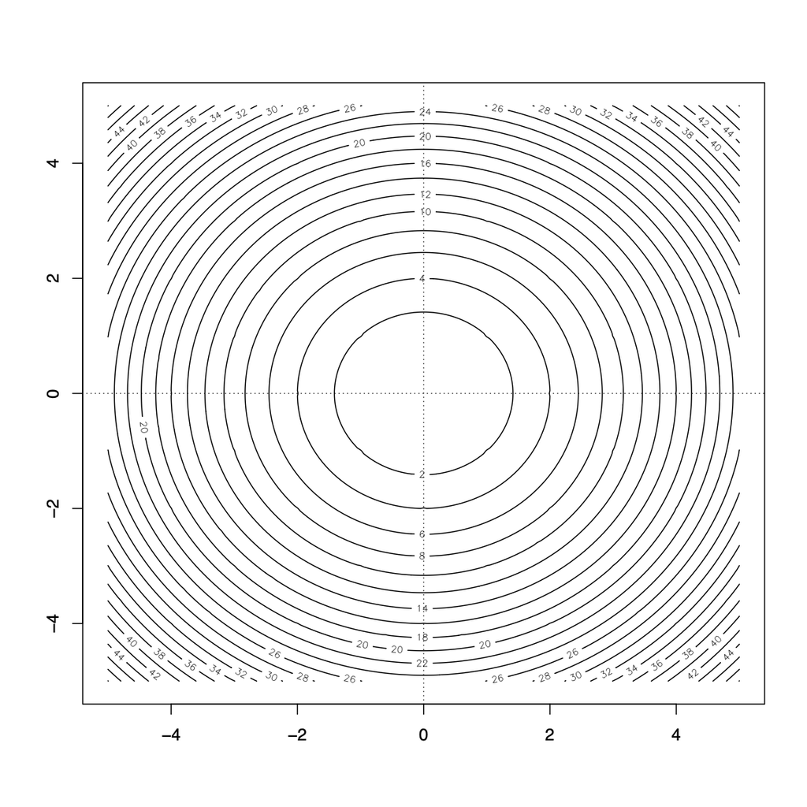

## Partial Derivatives using Function Table

**Example:** The *wind chill* is a function $w(v, T)$ of the wind speed $v$ (in $\frac{m}{hr}$) and temperature $T$ (in degrees $F$). Estimate $w_T(20, -15)$ and $w_v(20, -15)$. Explain what they mean.

| $\boldsymbol{v \backslash T}$ | $\boldsymbol{-30}$ | $\boldsymbol{-25}$ | $\boldsymbol{-20}$ | $\boldsymbol{-15}$ | $\boldsymbol{-10}$ | $\boldsymbol{-5}$ | $\boldsymbol{0}$ | $\boldsymbol{5}$ | $\boldsymbol{10}$ | $\boldsymbol{15}$ | $\boldsymbol{20}$ |
| --- | --- | --- | --- | --- | --- | --- | --- | --- | --- | --- | --- |
| $\boldsymbol{5}$ | $-46$ | $-40$ | $-34$ | $-28$ | $-22$ | $-16$ | $-11$ | $-5$ | $1$ | $7$ | $13$ |
| $\boldsymbol{10}$ | $-53$ | $-47$ | $-41$ | $-35$ | $-28$ | $-22$ | $-16$ | $-10$ | $-4$ | $3$ | $9$ |
| $\boldsymbol{15}$ | $-58$ | $-51$ | $-45$ | $-39$ | $-32$ | $-26$ | $-19$ | $-13$ | $-7$ | $0$ | $6$ |
| $\boldsymbol{20}$ | $-61$ | $-55$ | $-48$ | $-42$ | $-35$ | $-29$ | $-22$ | $-15$ | $-9$ | $-2$ | $4$ |
| $\boldsymbol{25}$ | $-64$ | $-58$ | $-51$ | $-44$ | $-37$ | $-31$ | $-24$ | $-17$ | $-11$ | $-4$ | $3$ |
| $\boldsymbol{30}$ | $-67$ | $-60$ | $-53$ | $-46$ | $-39$ | $-33$ | $-26$ | $-19$ | $-12$ | $-5$ | $1$ |
| $\boldsymbol{35}$ | $-69$ | $-62$ | $-55$ | $-48$ | $-41$ | $-34$ | $-27$ | $-21$ | $-14$ | $-7$ | $0$ |
| $\boldsymbol{40}$ | $-71$ | $-64$ | $-57$ | $-50$ | $-43$ | $-36$ | $-29$ | $-22$ | $-15$ | $-8$ | $-1$ |

## Partial Derivatives and Concavity

$\dfrac{\partial f}{\partial x} = f_x(a, b)$ represents the rate of change of $f(x, y)$ in the $x$-direction at the point $(a, b)$.

$\dfrac{\partial f}{\partial y} = f_y(a, b)$ represents the rate of change of $f(x, y)$ in the $y$-direction at the point $(a, b)$.

## Partial Derivatives and Concavity

$\dfrac{\partial^2 f}{\partial x^2} = f_{xx}(a, b)$ represents the concavity of $f(x, y)$ in the $x$-direction at the point $(a, b)$.

$\dfrac{\partial^2 f}{\partial y^2} = f_{yy}(a, b)$ represents the concavity of $f(x, y)$ in the $y$-direction at the point $(a, b)$.

## Partial Derivative Functions

If we want the function form of the partial derivative, treat the variable not being derived on as a constant and derive as if it was a single variable function.

When computing $\partial_x$ , hold $y$ constant and use the usual rules for finding derivatives as a function of $x$.

When computing $\partial_y$ , hold $x$ constant and use the usual rules for finding derivatives as a function of $y$.

## Example: Partial Derivatives

**Example:** Let $f(x, y) = yx^2 + 3xy^2$.

1. Find $\dfrac{\partial f}{\partial x}$.
2. Find $f_y$.

## Example: Partial Derivatives

**Example:** Let $g(x, y) = \dfrac{xy+y^2+x^2}{y+x}$.

1. Find $\dfrac{\partial g}{\partial x}$.
2. Find $g_y$.

**Example:** Find $\dfrac{\partial^2 f}{\partial y \partial x} (3, 2)$ if $f(x, y) = x^2 + y^2$.

## Example: Higher-Order Partial Derivatives

**Example:** Let $h(x, y) = -4 x^3 y^2$.

1. Find $h_{xx}$.
2. Find $h_{yy}$.
3. Find $\dfrac{\partial^2 h}{\partial x \partial y}$.
4. Find $\dfrac{\partial^2 h}{\partial y \partial x}$.